[GitHub](https://github.com/JuliaGeometry/DelaunayTriangulation.jl)[](https://github.com/JuliaGeometry/DelaunayTriangulation.jl/tree/main/docs/src/literate_tutorials/constrained_edges.jl)

# Constrained Triangulations

## Constrained Segments

In this tutorial, we introduce constrained triangulations, starting with the simple case of only having constrained segments, meaning edges that are forced to be in the final triangulation. To start, let us load in the packages we will need.

```julia
using DelaunayTriangulation
using CairoMakie
```

We consider triangulating the following set of points:

```julia
a = (0.0, 0.0)
b = (0.0, 1.0)
c = (0.0, 2.5)
d = (2.0, 0.0)
e = (6.0, 0.0)
f = (8.0, 0.0)
g = (8.0, 0.5)
h = (7.5, 1.0)
i = (4.0, 1.0)
j = (4.0, 2.5)
k = (8.0, 2.5)
pts = [a, b, c, d, e, f, g, h, i, j, k]
```

```
11-element Vector{Tuple{Float64, Float64}}:
 (0.0, 0.0)
 (0.0, 1.0)
 (0.0, 2.5)
 (2.0, 0.0)
 (6.0, 0.0)
 (8.0, 0.0)
 (8.0, 0.5)
 (7.5, 1.0)
 (4.0, 1.0)
 (4.0, 2.5)
 (8.0, 2.5)
```

To now define the segments, we define:

```julia
C = Set([(2, 1), (2, 11), (2, 7), (2, 5)])
```

```
Set{Tuple{Int64, Int64}} with 4 elements:
  (2, 5)
  (2, 11)
  (2, 1)
  (2, 7)
```

With this notation, each `Tuple` is an individual edge to include in the triangulation, with `(i, j)` meaning the edge connecting the points `pts[i]` and `pts[j]` together. Let us now make the triangulation, comparing it to its unconstrained counterpart.

```julia
tri = triangulate(pts)
```

```
Delaunay Triangulation.
   Number of vertices: 11
   Number of triangles: 11
   Number of edges: 21
   Has boundary nodes: false
   Has ghost triangles: true
   Curve-bounded: false
   Weighted: false
   Constrained: false
```

```julia
cons_tri = triangulate(pts; segments=C)
```

```
Delaunay Triangulation.
   Number of vertices: 11
   Number of triangles: 11
   Number of edges: 21
   Has boundary nodes: false
   Has ghost triangles: true
   Curve-bounded: false
   Weighted: false
   Constrained: true
```

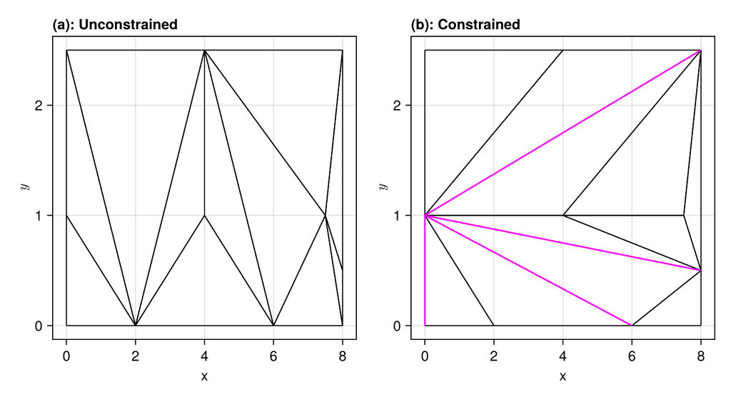

```julia
fig = Figure()
ax1 = Axis(fig[1, 1], xlabel="x", ylabel=L"y",
    title="(a): Unconstrained", titlealign=:left,
    width=300, height=300)
ax2 = Axis(fig[1, 2], xlabel="x", ylabel=L"y",
    title="(b): Constrained", titlealign=:left,
    width=300, height=300)
triplot!(ax1, tri)
triplot!(ax2, cons_tri, show_constrained_edges = true)
resize_to_layout!(fig)
fig
```

As you can see, the constrained edges in magenta have now been included in the triangulation in (b), whereas in (a) most were previously not included.

You can view the constrained edges by using

```julia
get_interior_segments(cons_tri)
```

```
Set{Tuple{Int64, Int64}} with 4 elements:
  (1, 2)
  (2, 5)
  (7, 2)
  (11, 2)
```

There is also a function `get_all_segments`, which in this case is the same as `get_interior_segments`, but in the case of a triangulation with constrained boundaries, it will also include the boundary segments whereas `get_interior_segments` will not; this is demonstrated in the later tutorials.

## Just the code

An uncommented version of this example is given below. You can view the source code for this file [here](https://github.com/JuliaGeometry/DelaunayTriangulation.jl/tree/main/docs/src/literate_tutorials/constrained_edges.jl).

```julia
using DelaunayTriangulation
using CairoMakie

a = (0.0, 0.0)
b = (0.0, 1.0)
c = (0.0, 2.5)
d = (2.0, 0.0)
e = (6.0, 0.0)
f = (8.0, 0.0)
g = (8.0, 0.5)
h = (7.5, 1.0)
i = (4.0, 1.0)
j = (4.0, 2.5)
k = (8.0, 2.5)
pts = [a, b, c, d, e, f, g, h, i, j, k]

C = Set([(2, 1), (2, 11), (2, 7), (2, 5)])

tri = triangulate(pts)

cons_tri = triangulate(pts; segments=C)

fig = Figure()
ax1 = Axis(fig[1, 1], xlabel="x", ylabel=L"y",
    title="(a): Unconstrained", titlealign=:left,
    width=300, height=300)
ax2 = Axis(fig[1, 2], xlabel="x", ylabel=L"y",
    title="(b): Constrained", titlealign=:left,
    width=300, height=300)
triplot!(ax1, tri)
triplot!(ax2, cons_tri, show_constrained_edges = true)
resize_to_layout!(fig)
fig

get_interior_segments(cons_tri)
```

*This page was generated using Literate.jl.*